## **Black-footed tree-rat**

### Blamed on cats

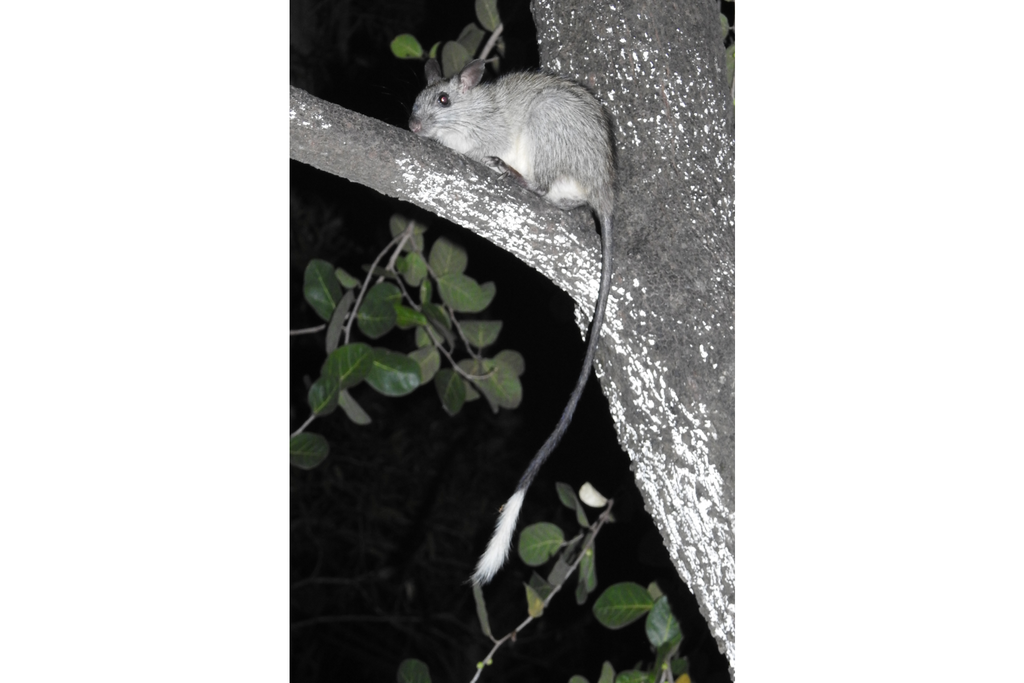

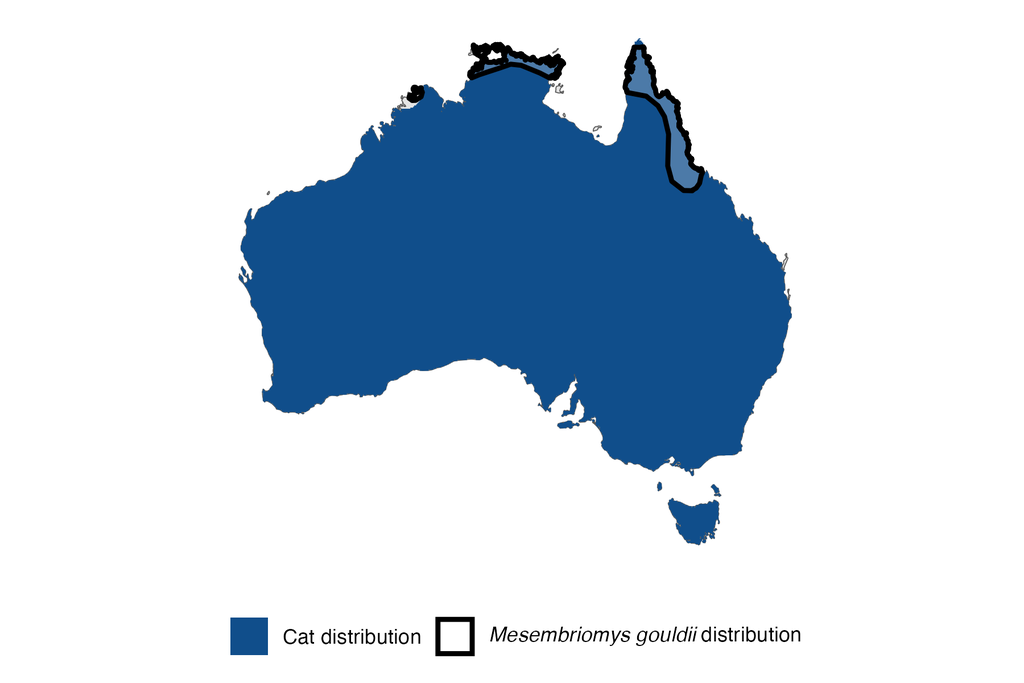

IUCN status: **Vulnerable**

EPBC Predator Threat Rating: **High**

IUCN claim: *“Major threats are predation by feral cats and habitat decline.”*

### Studies in support

Lower tree-rat occupancy was correlated with higher cat occupancy across Melville Island and north of Northern Territory mainland (Stobo-Wilson et al. 2020). Cats hunt tree-rats (Stokeld et al. 2018).

### Studies not in support

No relationship between cat detection and tree-rat detection on Melville Island (Davies et al. 2018).

### Is the threat claim evidence-based?

Cats have been documented among a range of ecological variables negatively correlated with black-footed tree rats in one study, but not in the other. Causality for decline cannot be inferred due to confounding variables and conflicting results.

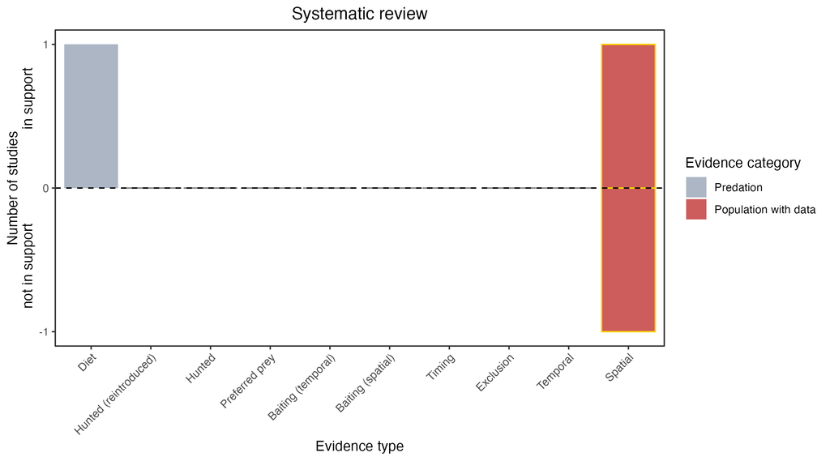

**Evidence linking *Mesembriomys gouldii* to cats.** Systematic review of evidence for an association between *Mesembriomys gouldii* and cats. Positive studies are in support of the hypothesis that *cats* contribute to the decline of Mesembriomys gouldii, negative studies are not in support. Predation studies include studies documenting hunting or scavenging; baiting studies are associations between poison baiting and threatened mammal abundance where information on predator abundance is not provided; population studies are associations between threatened mammal and predator abundance. Gold borders indicate studies that meet qualities of scientific rigour. See methods section in Wallach and Lundgren 2025 for details on evidence categories.

### References

Davies, H.F., McCarthy, M.A., Firth, R.S., Woinarski, J.C., Gillespie, G.R., Andersen, A.N., Rioli, W., Puruntatameri, J., Roberts, W., Kerinaiua, C. and Kerinauia, V., 2018. Declining populations in one of the last refuges for threatened mammal species in northern Australia. Austral Ecology, 43(5), pp.602-612.

EPBC. (2015) Threat Abatement Plan for Predation by Feral Cats. Environment Protection and Biodiversity Conservation Act 1999, Department of Environment, Government of Australia. (Table A1).

IUCN Red List. https://www.iucnredlist.org/ Accessed June 2023

Stobo-Wilson, A.M., Stokeld, D., Einoder, L.D., Davies, H.F., Fisher, A., Hill, B.M., Mahney, T., Murphy, B.P., Scroggie, M.P., Stevens, A. and Woinarski, J.C.Z., 2020. Bottom-up and top-down processes influence contemporary patterns of mammal species richness in Australia’s monsoonal tropics. Biological Conservation, 247, p.108638.

Stokeld D, Fisher A, Gentles T, Hill B, Triggs B, Woinarski JCZ, Gillespie GR. 2018. What do predator diets tell us about mammal declines in Kakadu National Park? Wildlife Research 45:92-101.

Wallach A.D., Lundgren E.J. (2025) Review of evidence that foxes and cats cause extinctions of Australia’s endemic mammals. BioScience. DOI: 10.1093/biosci/biaf046